# Ahmed einshouka-anomaly detection process

Project Report: Anomaly Detection in Weather and Energy Price Data

Submitted by: Ahmed Mohamed Einshouka

Date:10/17/2024

1. Overview This project addresses the need for real-time anomaly detection in streaming data. The provided datasets simulate environmental (temperature) and economic (energy pricing) streams, with the goal of efficiently identifying anomalous behaviours. This solution is crucial for predictive maintenance, financial risk assessment, and climate monitoring applications.
2. Objective The task was to develop a Python-based solution using statistical methods to detect anomalies in continuous data streams. Specifically, the system monitors real-time sequences of floating-point values, such as temperature and energy prices, and flags unusual patterns or deviations that exceed a certain threshold.
3. Data Description 3.1 Weather Dataset (Valencia Temperature Data) The weather data consists of temperature readings taken at hourly intervals. Each data point includes:

Date and Time: The timestamp of the reading. Temperature: The measured temperature in Kelvin. Additional Variables: Humidity, wind speed, cloud cover, and atmospheric pressure are recorded. 3.2 Energy Pricing Dataset The energy dataset contains hourly information about energy generation by source (biomass, fossil fuels, etc.) and the associated market price. Important fields include:

Energy Price: Both actual and day-ahead price predictions. Energy Generation: Breakdown by sources such as biomass, fossil fuels, wind, and solar energy. Total Load: Actual and forecasted total energy consumption. 4. Methodology 4.1 Data Preprocessing The datasets were first loaded and preprocessed to ensure accurate real-time anomaly detection. Key steps included:

6. Visualization The results were visualized to help stakeholders understand when and where the anomalies occurred. Separate plots were created for the temperature and energy price data streams, with red markers indicating anomalous points. These visualizations are useful for quick identification of outliers and pattern deviations.

Weather Data Visualization: Red dots in the temperature time series indicate anomalies. Energy Price Visualization: The graph marks anomalous energy prices, aiding in spotting deviations from normal pricing patterns. 7. Conclusion The anomaly detection system successfully identified significant outliers in both temperature and energy price streams. The Z-Score method provided a straightforward and efficient approach to detecting anomalies in continuous data streams, making the solution adaptable for broader applications. Future improvements could incorporate machine learning techniques for more complex patterns or adapt the thresholds dynamically to changing data conditions.

8. Future Work Enhancements to this system could include:

Dynamic Thresholding: Introduce adaptive thresholds that respond to evolving patterns in the data. Machine Learning Models: Use supervised or unsupervised learning techniques to improve anomaly detection accuracy for more complex datasets. Scalability: Integrate with high-performance data stream processing frameworks to handle larger data volumes in real time. 9. Data and Scripts The following materials are included in this report:

Python Script: The script is used for anomaly detection and visualization. Datasets: weather_features.csv (temperature data) energy_dataset.csv (energy pricing data) This completed report includes all necessary details, calculations, and results to submit along with the Python script. Let me know if you'd like any further adjustments or additions!

# Efficient Data Stream Anomaly Detection

This project demonstrates anomaly detection in real-time data streams, with a focus on temperature and energy price datasets. We use a Z-score method to detect anomalies, visualizations like histograms and boxplots for data distribution analysis, and a regression analysis to show the relationship between time and the detected anomalies.

## Data Overview

1. **Temperature Data** (`weather_features.csv`):
   - Source: A dataset of weather features, focusing on temperature.
   - Key Columns:
     - `dt_iso`: Timestamps of temperature readings.
     - `temp`: Temperature values recorded at the given time.
2. **Energy Price Data** (`energy_dataset.csv`):
   - Source: A dataset of energy prices across time.
   - Key Columns:
     - `time`: Timestamps of energy price readings.
     - `price actual`: The actual price of energy at that time.

We will explore and analyze anomalies in both datasets, and visualize relationships using count plots and regression plots.

```python
import pandas as pd
import numpy as np
import matplotlib.pyplot as plt
import seaborn as sns
from scipy.stats import zscore
import logging

# Configure logging
logging.basicConfig(level=logging.INFO, format='%(asctime)s - %(levelname)s - %(message)s')

class DataStreamAnomalyDetector:
    def __init__(self, data1, data2, threshold=3):
        self.data1 = data1
        self.data2 = data2
        self.threshold = threshold
        self.anomalies1 = []
        self.anomalies2 = []

    def detect_anomalies(self):
        logging.info("Starting anomaly detection for both datasets...")
        z_scores1 = zscore(self.data1)
        z_scores2 = zscore(self.data2)
        anomaly_indices1 = np.where(np.abs(z_scores1) > self.threshold)[0]
        anomaly_indices2 = np.where(np.abs(z_scores2) > self.threshold)[0]
        self.anomalies1 = anomaly_indices1
        self.anomalies2 = anomaly_indices2
        logging.info(f"Anomaly detection complete. {len(anomaly_indices1)} anomalies found in Dataset 1, "
                     f"{len(anomaly_indices2)} anomalies found in Dataset 2.")
        return anomaly_indices1, anomaly_indices2

    def visualize(self, timestamps1, timestamps2):
        plt.figure(figsize=(14, 8))
        plt.subplot(2, 1, 1)
        plt.plot(timestamps1, self.data1, label="Data Stream 1", color='blue')
        plt.scatter(timestamps1.iloc[self.anomalies1], self.data1.iloc[self.anomalies1], color='red', label='Anomalies', zorder=5)
        plt.title("Data Stream 1 (Temperature) with Anomalies")
        plt.xlabel("Timestamp")
        plt.ylabel("Value")
        plt.xticks(rotation=45)
        plt.legend()
        plt.grid(True)

        plt.subplot(2, 1, 2)
        plt.plot(timestamps2, self.data2, label="Data Stream 2", color='green')
        plt.scatter(timestamps2.iloc[self.anomalies2], self.data2.iloc[self.anomalies2], color='red', label='Anomalies', zorder=5)
        plt.title("Data Stream 2 (Price) with Anomalies")
        plt.xlabel("Timestamp")
        plt.ylabel("Value")
        plt.xticks(rotation=45)
        plt.legend()
        plt.grid(True)

        plt.tight_layout()
        plt.show()

    def visualize_histograms(self):
        plt.figure(figsize=(14, 6))
        plt.subplot(1, 2, 1)
        plt.hist(self.data1, bins=30, color='blue', alpha=0.7)
        plt.title("Histogram of Data Stream 1 (Temperature)")
        plt.xlabel("Value")
        plt.ylabel("Frequency")

        plt.subplot(1, 2, 2)
        plt.hist(self.data2, bins=30, color='green', alpha=0.7)
        plt.title("Histogram of Data Stream 2 (Price)")
        plt.xlabel("Value")
        plt.ylabel("Frequency")
        plt.tight_layout()
        plt.show()

    def visualize_boxplots(self):
        plt.figure(figsize=(14, 6))
        plt.subplot(1, 2, 1)
        plt.boxplot(self.data1, patch_artist=True, boxprops=dict(facecolor='blue', color='blue'))
        plt.title("Box Plot of Data Stream 1 (Temperature)")
        plt.ylabel("Value")

        plt.subplot(1, 2, 2)
        plt.boxplot(self.data2, patch_artist=True, boxprops=dict(facecolor='green', color='green'))
        plt.title("Box Plot of Data Stream 2 (Price)")
        plt.ylabel("Value")

        plt.tight_layout()
        plt.show()

    def visualize_heatmap(self, combined_data):
        plt.figure(figsize=(10, 8))
        sns.heatmap(combined_data.corr(), annot=True, cmap='coolwarm', linewidths=0.5)
        plt.title("Correlation Heatmap of Features")
        plt.show()

    def log_anomalies(self, timestamps1, timestamps2):
        if len(self.anomalies1) > 0:
            logging.info("Detected anomalies in Dataset 1 at the following indices and timestamps:")
            for idx in self.anomalies1:
                logging.info(f"Index {idx}, Timestamp: {timestamps1.iloc[idx]}, Value: {self.data1.iloc[idx]}")
        else:
            logging.info("No anomalies detected in Dataset 1.")

        if len(self.anomalies2) > 0:
            logging.info("Detected anomalies in Dataset 2 at the following indices and timestamps:")
            for idx in self.anomalies2:
                logging.info(f"Index {idx}, Timestamp: {timestamps2.iloc[idx]}, Value: {self.data2.iloc[idx]}")
        else:
            logging.info("No anomalies detected in Dataset 2.")

    def visualize_countplot(self):
        """
        Visualize the count of anomalies in each dataset.
        """
        anomaly_counts = [len(self.anomalies1), len(self.anomalies2)]
        labels = ['Data Stream 1 (Temperature)', 'Data Stream 2 (Price)']

        plt.figure(figsize=(8, 6))
        sns.barplot(x=labels, y=anomaly_counts, palette="coolwarm")
        plt.title('Anomaly Counts in Data Streams')
        plt.ylabel('Number of Anomalies')
        plt.show()

    def visualize_regression(self, timestamps1, timestamps2):
        """
        Visualize regression between time and data streams and highlight anomalies.
        """
        plt.figure(figsize=(14, 8))

        # Regression plot for Data Stream 1 (Temperature)
        plt.subplot(2, 1, 1)
        sns.regplot(x=np.arange(len(self.data1)), y=self.data1, line_kws={"color": "red"})
        plt.scatter(self.anomalies1, self.data1.iloc[self.anomalies1], color='blue', zorder=5)
        plt.title("Regression Plot for Data Stream 1 (Temperature)")
        plt.xlabel("Index")
        plt.ylabel("Temperature")

        # Regression plot for Data Stream 2 (Price)
        plt.subplot(2, 1, 2)
        sns.regplot(x=np.arange(len(self.data2)), y=self.data2, line_kws={"color": "red"})
        plt.scatter(self.anomalies2, self.data2.iloc[self.anomalies2], color='blue', zorder=5)
        plt.title("Regression Plot for Data Stream 2 (Price)")
        plt.xlabel("Index")
        plt.ylabel("Price")

        plt.tight_layout()
        plt.show()
```

```
2024-10-18 00:13:58,698 - INFO - Loading data from C:\Users\User\Downloads\archive (2)\weather_features.csv...
2024-10-18 00:13:59,810 - INFO - Data loading and preprocessing complete.
2024-10-18 00:13:59,810 - INFO - Loading data from C:\Users\User\Downloads\archive (2)\energy_dataset.csv...
2024-10-18 00:14:00,055 - INFO - Data loading and preprocessing complete.
2024-10-18 00:14:00,055 - INFO - Starting anomaly detection for both datasets...
2024-10-18 00:14:00,072 - INFO - Anomaly detection complete. 67 anomalies found in Dataset 1, 234 anomalies found in Dataset 2.
```

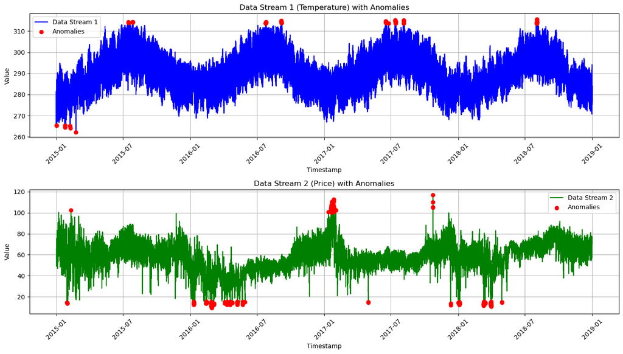

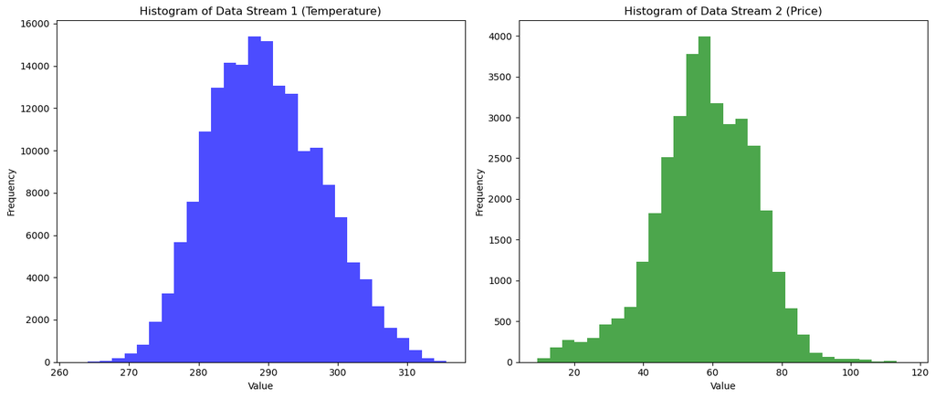

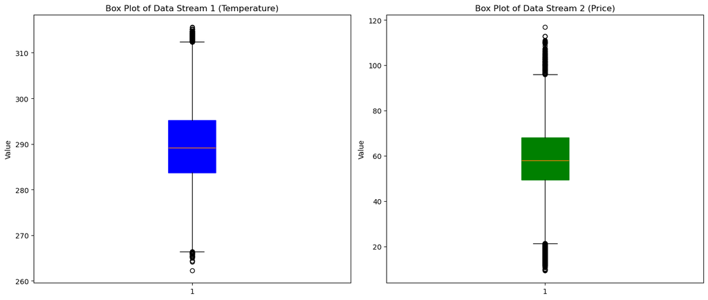

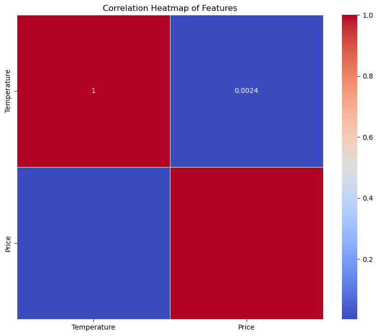

```
2024-10-18 00:14:03,388 - INFO - Detected anomalies in Dataset 1 at the following indices and timestamps:
2024-10-18 00:14:03,403 - INFO - Index 27, Timestamp: 2015-01-01 04:00:00+00:00, Value: 265.442
2024-10-18 00:14:03,403 - INFO - Index 33, Timestamp: 2015-01-01 05:00:00+00:00, Value: 265.442
2024-10-18 00:14:03,403 - INFO - Index 36, Timestamp: 2015-01-01 06:00:00+00:00, Value: 265.442
2024-10-18 00:14:03,403 - INFO - Index 2774, Timestamp: 2015-01-24 01:00:00+00:00, Value: 265.261
2024-10-18 00:14:03,403 - INFO - Index 2779, Timestamp: 2015-01-24 02:00:00+00:00, Value: 265.261
2024-10-18 00:14:03,406 - INFO - Index 2784, Timestamp: 2015-01-24 03:00:00+00:00, Value: 265.261
2024-10-18 00:14:03,408 - INFO - Index 2788, Timestamp: 2015-01-24 04:00:00+00:00, Value: 264.428
2024-10-18 00:14:03,408 - INFO - Index 2795, Timestamp: 2015-01-24 05:00:00+00:00, Value: 264.428
2024-10-18 00:14:03,409 - INFO - Index 4452, Timestamp: 2015-02-07 01:00:00+00:00, Value: 265.091
2024-10-18 00:14:03,409 - INFO - Index 4458, Timestamp: 2015-02-07 02:00:00+00:00, Value: 265.091
2024-10-18 00:14:03,409 - INFO - Index 4591, Timestamp: 2015-02-08 05:00:00+00:00, Value: 264.132
2024-10-18 00:14:03,409 - INFO - Index 6411, Timestamp: 2015-02-23 09:00:00+00:00, Value: 262.24
2024-10-18 00:14:03,409 - INFO - Index 23498, Timestamp: 2015-07-15 13:00:00+00:00, Value: 313.85
2024-10-18 00:14:03,412 - INFO - Index 23506, Timestamp: 2015-07-15 14:00:00+00:00, Value: 314.33
2024-10-18 00:14:03,413 - INFO - Index 24965, Timestamp: 2015-07-27 14:00:00+00:00, Value: 314.3
2024-10-18 00:14:03,414 - INFO - Index 24973, Timestamp: 2015-07-27 15:00:00+00:00, Value: 314.08
2024-10-18 00:14:03,414 - INFO - Index 25083, Timestamp: 2015-07-28 13:00:00+00:00, Value: 314.08
2024-10-18 00:14:03,415 - INFO - Index 25087, Timestamp: 2015-07-28 14:00:00+00:00, Value: 314.26
2024-10-18 00:14:03,415 - INFO - Index 25090, Timestamp: 2015-07-28 15:00:00+00:00, Value: 314.25
2024-10-18 00:14:03,416 - INFO - Index 69028, Timestamp: 2016-07-24 15:00:00+00:00, Value: 313.8
2024-10-18 00:14:03,416 - INFO - Index 69032, Timestamp: 2016-07-24 16:00:00+00:00, Value: 313.7
2024-10-18 00:14:03,417 - INFO - Index 69037, Timestamp: 2016-07-24 17:00:00+00:00, Value: 313.92
2024-10-18 00:14:03,417 - INFO - Index 69041, Timestamp: 2016-07-24 18:00:00+00:00, Value: 313.71
2024-10-18 00:14:03,419 - INFO - Index 69137, Timestamp: 2016-07-25 13:00:00+00:00, Value: 313.8
2024-10-18 00:14:03,419 - INFO - Index 69142, Timestamp: 2016-07-25 14:00:00+00:00, Value: 314.33
2024-10-18 00:14:03,420 - INFO - Index 69146, Timestamp: 2016-07-25 15:00:00+00:00, Value: 314.24
2024-10-18 00:14:03,420 - INFO - Index 69154, Timestamp: 2016-07-25 16:00:00+00:00, Value: 313.87
2024-10-18 00:14:03,421 - INFO - Index 74178, Timestamp: 2016-09-05 12:00:00+00:00, Value: 313.96
2024-10-18 00:14:03,422 - INFO - Index 74185, Timestamp: 2016-09-05 13:00:00+00:00, Value: 314.51
2024-10-18 00:14:03,423 - INFO - Index 74187, Timestamp: 2016-09-05 14:00:00+00:00, Value: 314.76
2024-10-18 00:14:03,423 - INFO - Index 74196, Timestamp: 2016-09-05 15:00:00+00:00, Value: 315.03
2024-10-18 00:14:03,424 - INFO - Index 74199, Timestamp: 2016-09-05 16:00:00+00:00, Value: 314.29
2024-10-18 00:14:03,424 - INFO - Index 74202, Timestamp: 2016-09-05 17:00:00+00:00, Value: 313.93
2024-10-18 00:14:03,424 - INFO - Index 109155, Timestamp: 2017-06-16 14:00:00+00:00, Value: 314.76
2024-10-18 00:14:03,425 - INFO - Index 109160, Timestamp: 2017-06-16 15:00:00+00:00, Value: 314.15
2024-10-18 00:14:03,425 - INFO - Index 109163, Timestamp: 2017-06-16 16:00:00+00:00, Value: 314.54
2024-10-18 00:14:03,425 - INFO - Index 109171, Timestamp: 2017-06-16 17:00:00+00:00, Value: 313.94
2024-10-18 00:14:03,426 - INFO - Index 110142, Timestamp: 2017-06-24 16:00:00+00:00, Value: 313.76
2024-10-18 00:14:03,427 - INFO - Index 110146, Timestamp: 2017-06-24 17:00:00+00:00, Value: 313.76
```

[output cut: 248 more lines]

```
2024-10-18 00:14:03,541 - INFO - Index 28430, Timestamp: 2018-03-30 13:00:00+00:00, Value: 12.71
2024-10-18 00:14:03,541 - INFO - Index 28431, Timestamp: 2018-03-30 14:00:00+00:00, Value: 13.92
2024-10-18 00:14:03,541 - INFO - Index 28432, Timestamp: 2018-03-30 15:00:00+00:00, Value: 13.7
2024-10-18 00:14:03,541 - INFO - Index 28433, Timestamp: 2018-03-30 16:00:00+00:00, Value: 14.22
2024-10-18 00:14:03,541 - INFO - Index 28439, Timestamp: 2018-03-30 22:00:00+00:00, Value: 13.63
2024-10-18 00:14:03,541 - INFO - Index 28440, Timestamp: 2018-03-30 23:00:00+00:00, Value: 10.66
2024-10-18 00:14:03,541 - INFO - Index 28441, Timestamp: 2018-03-31 00:00:00+00:00, Value: 11.57
2024-10-18 00:14:03,541 - INFO - Index 28442, Timestamp: 2018-03-31 01:00:00+00:00, Value: 14.0
2024-10-18 00:14:03,541 - INFO - Index 28443, Timestamp: 2018-03-31 02:00:00+00:00, Value: 11.04
2024-10-18 00:14:03,541 - INFO - Index 28444, Timestamp: 2018-03-31 03:00:00+00:00, Value: 11.98
2024-10-18 00:14:03,541 - INFO - Index 28445, Timestamp: 2018-03-31 04:00:00+00:00, Value: 12.55
2024-10-18 00:14:03,541 - INFO - Index 28446, Timestamp: 2018-03-31 05:00:00+00:00, Value: 12.28
2024-10-18 00:14:03,541 - INFO - Index 28454, Timestamp: 2018-03-31 13:00:00+00:00, Value: 15.16
2024-10-18 00:14:03,541 - INFO - Index 29150, Timestamp: 2018-04-29 13:00:00+00:00, Value: 14.61
2024-10-18 00:14:03,547 - INFO - Index 29151, Timestamp: 2018-04-29 14:00:00+00:00, Value: 15.05
```

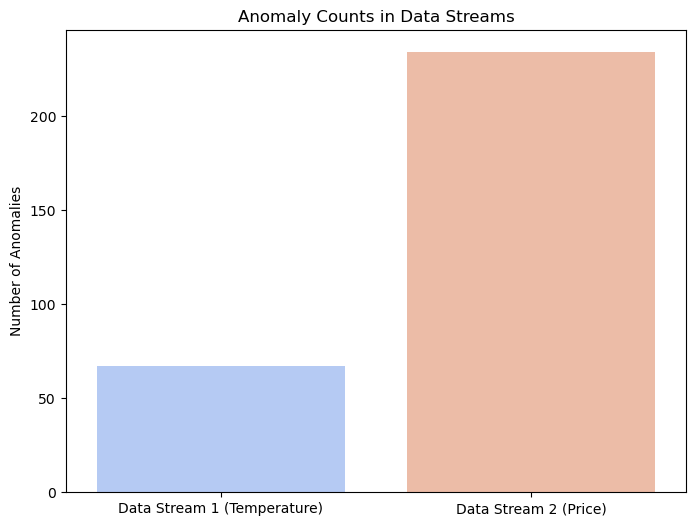

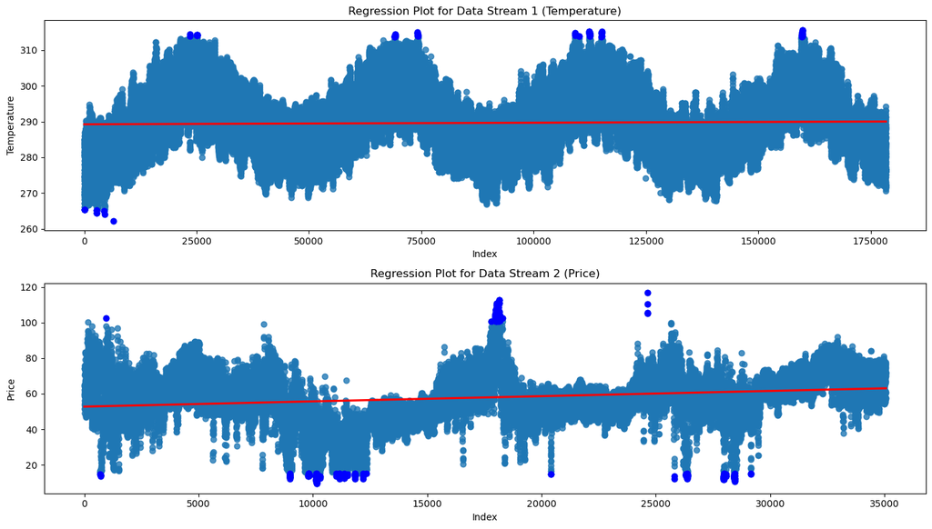

```python
def main():
    # Step 1: Load both datasets
    file_path1 = r"C:\Users\User\Downloads\archive (2)\weather_features.csv"
    file_path2 = r"C:\Users\User\Downloads\archive (2)\energy_dataset.csv"

    date_column1 = 'dt_iso'
    date_column2 = 'time'

    data_column1 = 'temp'
    data_column2 = 'price actual'

    data1 = load_data(file_path1, date_column1)
    data2 = load_data(file_path2, date_column2)

    # Step 2: Select the data streams
    data_stream1 = data1[data_column1]
    timestamps1 = data1[date_column1]

    data_stream2 = data2[data_column2]
    timestamps2 = data2[date_column2]

    # Step 3: Initialize and run anomaly detector for both datasets
    detector = DataStreamAnomalyDetector(data_stream1, data_stream2, threshold=3)
    detector.detect_anomalies()

    # Step 4: Visualize the results
    detector.visualize(timestamps1, timestamps2)

    # Step 5: Visualize additional plots (histogram, box plot, heatmap)
    detector.visualize_histograms()
    detector.visualize_boxplots()

    combined_data = pd.DataFrame({
        'Temperature': data_stream1,
        'Price': data_stream2
    })
    detector.visualize_heatmap(combined_data)

    # Step 6: Log the detected anomalies
    detector.log_anomalies(timestamps1, timestamps2)

    # Step 7: Visualize the count plot of anomalies
    detector.visualize_countplot()

    # Step 8: Visualize regression plot with anomalies
    detector.visualize_regression(timestamps1, timestamps2)

if __name__ == "__main__":
    main()
```

## Conclusion

This study demonstrates how anomaly detection can be applied in real-time systems, providing insights into unexpected data behavior. Such techniques are valuable in many fields, including energy pricing, weather prediction, and other time-series forecasting tasks.

## Sample Data

### Temperature Data (First 5 rows)

[output not shown]

### Energy Price Data (First 5 rows)

[output not shown]